# Sex-dependent response calling in Thyroptera tricolor

Statistical analysis

[Marcelo Araya-Salas](http://marceloarayasalas.weebly.com/)

2020-09-29

```r
# path to project directory
knitr::opts_knit$set(root.dir = normalizePath(".."))

# fig quality
knitr::opts_chunk$set(dpi = 50, fig.width = 12)
```

## Exploratory graphs

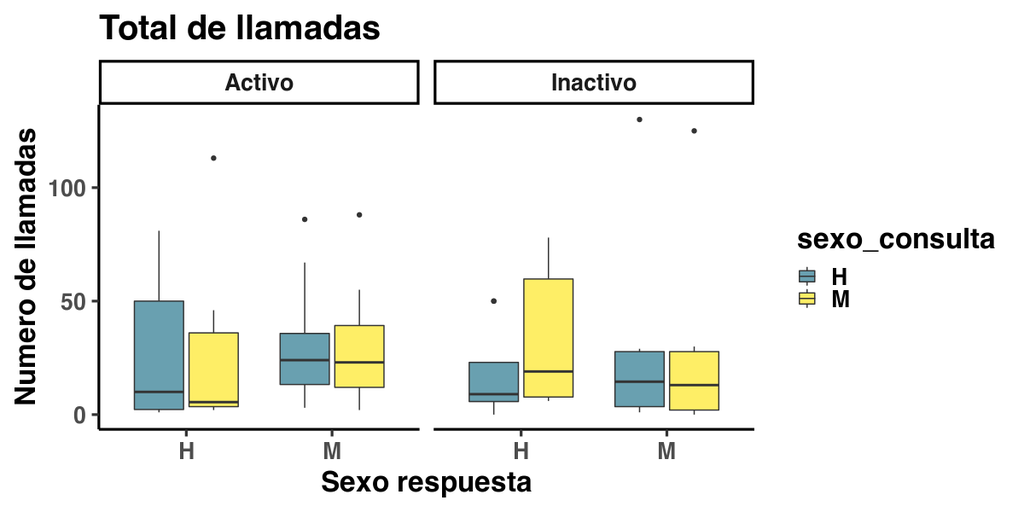

```r
# read data
dat <- read_excel("./data/Datos de respuestas_cap2.xlsx")

# convert to regular data frame
dat <- as.data.frame(dat)

# create new variable abou
dat$est_repr[dat$estado_repr == 0] <- "Inactivo"
dat$est_repr[dat$estado_repr == 1] <- "Activo"

# aggregate total number of calls
agg_dat <- aggregate(n_llamadas ~ ID + sexo_consulta + sexo_respuesta + est_repr, data = dat, FUN = sum)

# plot
ggplot(agg_dat, aes(fill = sexo_consulta, y = n_llamadas, x = sexo_respuesta)) +
geom_boxplot() +
  scale_fill_viridis_d(alpha = 0.7, begin = 0.4) +
theme_classic(base_size = 24) +
  labs(x = "Sexo respuesta", y = "Numero de llamadas")+
facet_wrap(~ est_repr) + ggtitle("Total de llamadas")
```

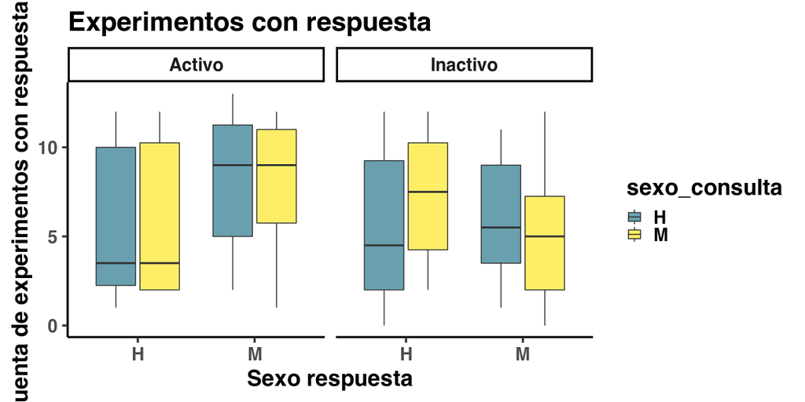

```r
# create binary variable for calling
dat$n_llam_bin <- ifelse(dat$n_llamadas > 0, 1, 0)

# aggregate
agg_dat2 <- aggregate(n_llam_bin ~ ID + sexo_consulta + sexo_respuesta + est_repr, data = dat, FUN = sum)

#plot
ggplot(agg_dat2, aes(fill = sexo_consulta, y = n_llam_bin, x = sexo_respuesta)) +
  geom_boxplot() +
  scale_fill_viridis_d(alpha = 0.7, begin = 0.4) +
  theme_classic(base_size = 24) +
  labs(x = "Sexo respuesta", y = "Cuenta de experimentos con respuesta")+
facet_wrap(~ est_repr) + ggtitle("Experimentos con respuesta")
```

## Multinomial mixed effect models (MCMCglmm)

- Including three-way interaction between ‘sex response’, ‘sex inquiry’ and ‘reproductive stage’, with individual ID as random effect:

```r
# define parmeters for MCMCglmm models
itrns <- 300000
burnin <- 3000
thin <- 1000

# prior for effect models
pr <- list(B = list(mu = rep(0, 8), V = diag(8) * (1 + pi^2/3)), R = list(V = 1, fix = 1),  G = list(G1 = list(V = 1, fix = 1)))

# run model
md <- MCMCglmm(n_llam_bin ~ sexo_respuesta:est_repr:sexo_consulta  - 1, random = ~ ID, data = dat, family = "categorical", prior = pr, verbose = FALSE, nitt = itrns, start = list(QUASI = FALSE), burnin = burnin, thin = thin)

saveRDS(md, "./output/MCMC_model_response_by_sex_test.RDS")
```

# Caculating p-values:

The output contains the posterior distribution of the parameter estimates. These parameter distributions can be used to test specific hypothesis about differences between sexes/stages/inquiry sexes. Column names in `md$Sol` (solutions) refer to the combination of levels from the 3 interacting variables:

```r
md <- readRDS("./output/MCMC_model_response_by_sex_test.RDS")


# simplify names
colnames(md$Sol) <- gsub("sexo_respuesta|est_repr", "", colnames(md$Sol))

colnames(md$Sol)
```

```
## [1] "H:Activo:sexo_consultaH"   "M:Activo:sexo_consultaH"
## [3] "H:Inactivo:sexo_consultaH" "M:Inactivo:sexo_consultaH"
## [5] "H:Activo:sexo_consultaM"   "M:Activo:sexo_consultaM"
## [7] "H:Inactivo:sexo_consultaM" "M:Inactivo:sexo_consultaM"
```

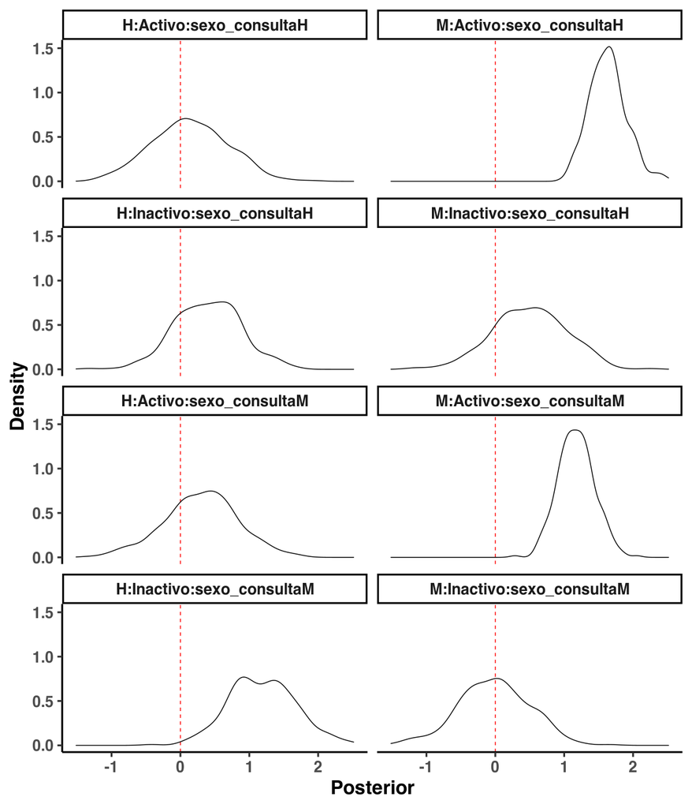

```r
# stack posteriors
Y <- stack(as.data.frame(md$Sol))

# plot posteriors
ggplot(Y, aes(x=values)) +
  geom_vline(xintercept = 0, col = "red", lty = 2) +
  geom_density() +
  labs(y = "Density", x = "Posterior") +
  facet_wrap(~ ind, ncol = 2) +
  theme_classic(base_size = 24)
```

```r
pvals <- round(sapply(unique(Y$ind), function(x) sum(Y$values[Y$ind ==x] <= 0) / sum(Y$ind ==x)), 3)

names(pvals) <- unique(Y$ind)

pvals
```

```
##   H:Activo:sexo_consultaH   M:Activo:sexo_consultaH H:Inactivo:sexo_consultaH
##                     0.401                     0.000                     0.222
## M:Inactivo:sexo_consultaH   H:Activo:sexo_consultaM   M:Activo:sexo_consultaM
##                     0.158                     0.273                     0.000
## H:Inactivo:sexo_consultaM M:Inactivo:sexo_consultaM
##                     0.003                     0.498
```

Estimates of the overlap of posteriors can be used a statistical significance test. For instance we can compare calling activity between sexes during the active stage:

```r
# p value
pvals <- pbapply::pbreplicate(1000, expr =
sum(md$Sol[sample(nrow(md$Sol)), "M:Activo:sexo_consultaH"] - md$Sol[, "H:Activo:sexo_consultaH"] < 0) / nrow(md$Sol)
)

mean(pvals)
```

```
## [1] 0.007164983
```

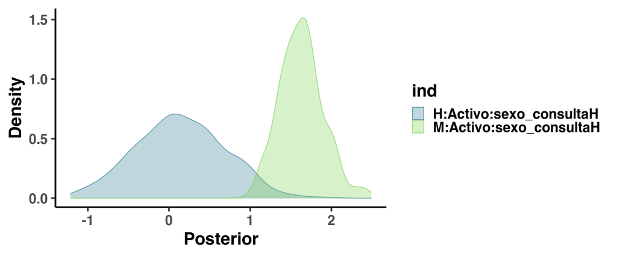

```r
# plot distributions
ggplot(Y[Y$ind %in% c("H:Activo:sexo_consultaH", "M:Activo:sexo_consultaH"), ], aes(x=values)) + geom_density(aes(group = ind, colour = ind, fill = ind), alpha=0.3) +
      scale_color_viridis_d(alpha = 0.7, begin = 0.4, end = 0.8) +
    scale_fill_viridis_d(alpha = 0.7, begin = 0.4, end = 0.8) +
  labs(y = "Density", x = "Posterior") +
  theme_classic(base_size = 24)
```

Or whether males responde more to females during the reproductive stage:

```r
# p value
pvals <- pbapply::pbreplicate(10000, expr =
sum(md$Sol[sample(nrow(md$Sol)), "M:Activo:sexo_consultaH"] - md$Sol[, "M:Inactivo:sexo_consultaH"] < 0) / nrow(md$Sol)
)

mean(pvals)

# plot distributions
ggplot(Y[Y$ind %in% c("M:Activo:sexo_consultaM", "M:Inactivo:sexo_consultaM"), ], aes(x=values)) + geom_density(aes(group = ind, colour = ind, fill = ind), alpha=0.3) +
    scale_color_viridis_d(alpha = 0.7, begin = 0.4, end = 0.8) +
    scale_fill_viridis_d(alpha = 0.7, begin = 0.4, end = 0.8) +
    labs(y = "Density", x = "Posterior") +
  theme_classic(base_size = 24)
```

[output not shown]

Whether males respond more often to females during the active period:

```r
# p value
pvals <- pbapply::pbreplicate(10000, expr =
sum(md$Sol[sample(nrow(md$Sol)), "M:Activo:sexo_consultaH"] - md$Sol[, "M:Activo:sexo_consultaM"] < 0) / nrow(md$Sol)
)

mean(pvals)
```

```
## [1] 0.10987
```

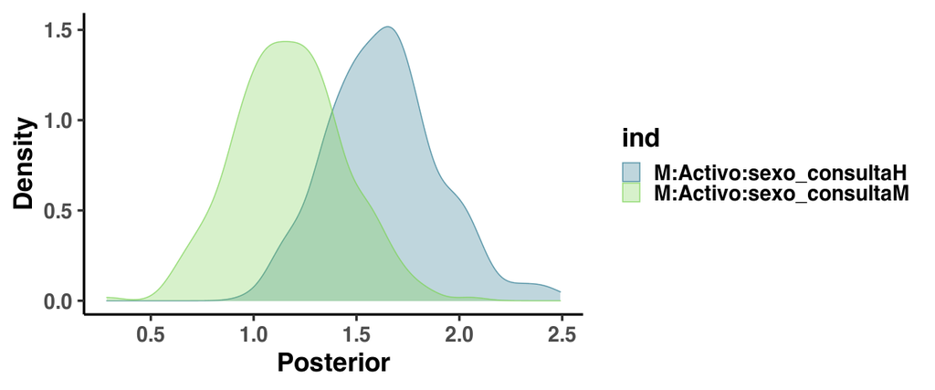

```r
# plot distributions
ggplot(Y[Y$ind %in% c("M:Activo:sexo_consultaH", "M:Activo:sexo_consultaM"), ], aes(x=values)) + geom_density(aes(group = ind, colour = ind, fill = ind), alpha=0.3) +
    scale_color_viridis_d(alpha = 0.7, begin = 0.4, end = 0.8) +
    scale_fill_viridis_d(alpha = 0.7, begin = 0.4, end = 0.8) +
    labs(y = "Density", x = "Posterior") +
  theme_classic(base_size = 24)
```

Whether females respond differentially to sexes:

```r
# p value
pvals <- pbapply::pbreplicate(10000, expr =
sum(md$Sol[sample(nrow(md$Sol)), "H:Inactivo:sexo_consultaM"] - md$Sol[, "H:Inactivo:sexo_consultaH"] < 0) / nrow(md$Sol)
)

mean(pvals)
```

```
## [1] 0.1214684
```

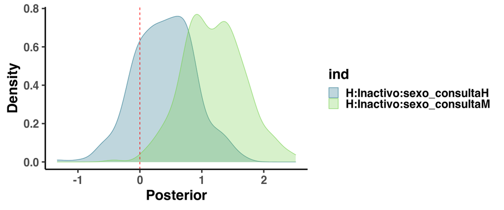

```r
# plot distributions
ggplot(Y[Y$ind %in% c("H:Inactivo:sexo_consultaM", "H:Inactivo:sexo_consultaH"), ], aes(x=values)) + geom_density(aes(group = ind, colour = ind, fill = ind), alpha=0.3) +
  geom_vline(xintercept = 0, lty = 2, col = "red") +
    scale_color_viridis_d(alpha = 0.7, begin = 0.4, end = 0.8) +
    scale_fill_viridis_d(alpha = 0.7, begin = 0.4, end = 0.8) +
    labs(y = "Density", x = "Posterior") +
  theme_classic(base_size = 24)
```

```r
# head(dat)

dat_dups <- lapply(1:nrow(dat), function(x){

  Y <- dat[x, ]
  if (Y$n_llamadas > 1)
  Z <- Y[rep(1, Y$n_llamadas), ]
  Z$playback <- as.character(x)

  return(Z)

})
```

#### Diagnostic plots

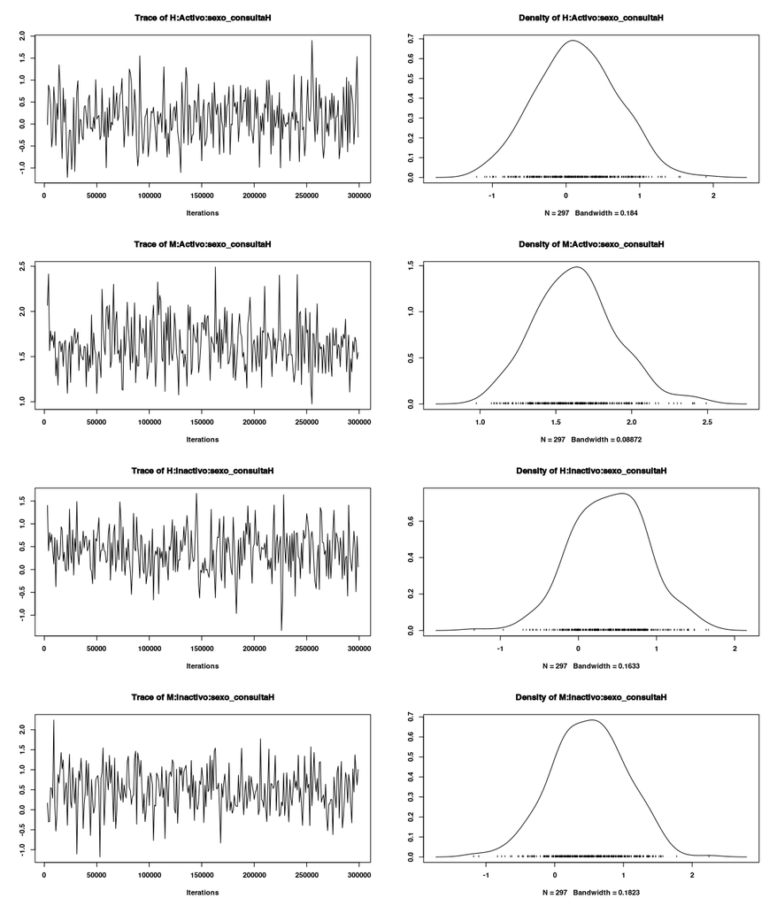

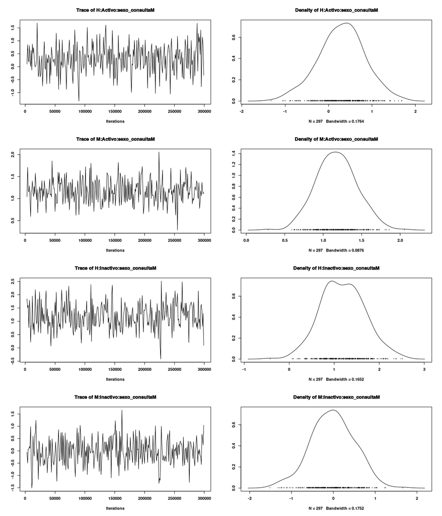

```r
plot(md$Sol)
```

## Sex discrimination using random forest

Measure acoustic structure on data from [call ontogeny paper](https://figshare.com/articles/dataset/Supplementary_materials_Ontogeny_of_an_interactive_call-and-response_system_in_Spix_s_disc-winged_bats_PART_1/11651772)

```r
# read extended selection table downloaded from figshare (ontogeny paper)
est <- readRDS("./data/ext_sel_tab_inquiry.RDS")

# keep adults only
est.adult <- est[est$age.class == "adults", ]

# check data
table(est.adult$sex)

# check number of calls per ID
tab <- table(est.adult$indiv)

# number of indiv with at least 4 calls
sum(tab > 4)

# keep indiv with at least 4 calls
est.adult.4 <- est.adult[est.adult$indiv %in% names(tab[tab > 4]), ]

# check again
table(est.adult.4$indiv, est.adult.4$sex)

# homogenize sampling rate
# est.adult.4 <- resample_est(est.adult.4, samp.rate = 375)

######## measure acoustic structure ######
# measure spectrographic parameters
sp <- specan(est.adult.4, wl = 1100)

# check if there are NAs
anyNA(sp)

# add random variable
sp$random <- rnorm(nrow(sp))

# measure cepstral coeffs
cc <- mfcc_stats(est.adult.4)

# bind all acoustic structure parameters together
sp.cc <- cbind(sp, cc[ , -c(1, 2)])

# scale
sp.cc[, -c(1, 2)] <- scale(sp.cc[, -c(1, 2)])

# add sex to data for random forest
sp.cc$sex <- est.adult.4$sex

write.csv(sp.cc, "./data/processed/acoustic_parameters_for_random_forest.csv", row.names = FALSE)
```

Model using both spectral parameters and MFCC

```r
sp.cc <- read.csv("./data/processed/acoustic_parameters_for_random_forest.csv")

# convert to factor
sp.cc$sex <- as.factor(sp.cc$sex)

# run RF model spectral and cepstral parameters
rfm <- ranger(sex ~ ., data = sp.cc[, -c(1, 2)], num.trees = 10000, importance = "impurity")

# model results (check out-of-bag error)
rfm
```

```
## Ranger result
##
## Call:
##  ranger(sex ~ ., data = sp.cc[, -c(1, 2)], num.trees = 10000,      importance = "impurity")
##
## Type:                             Classification
## Number of trees:                  10000
## Sample size:                      264
## Number of independent variables:  208
## Mtry:                             14
## Target node size:                 1
## Variable importance mode:         impurity
## Splitrule:                        gini
## OOB prediction error:             10.61 %
```

```r
# variable importance
imp <- rfm$variable.importance
```

Model using spectral parameters

```r
# run RF model only spectral parameters
rfm_sp <- ranger(sex ~ ., data = sp.cc[, -c(1, 2, grep("\\.cc", names(sp.cc)))], num.trees = 10000, importance = "impurity")

# model results (check out-of-bag error)
rfm_sp
```

```
## Ranger result
##
## Call:
##  ranger(sex ~ ., data = sp.cc[, -c(1, 2, grep("\\.cc", names(sp.cc)))],      num.trees = 10000, importance = "impurity")
##
## Type:                             Classification
## Number of trees:                  10000
## Sample size:                      264
## Number of independent variables:  29
## Mtry:                             5
## Target node size:                 1
## Variable importance mode:         impurity
## Splitrule:                        gini
## OOB prediction error:             23.48 %
```

Model using MFCC

```r
# run RF model only spectral parameters
rfm_cc <- ranger(sex ~ ., data = sp.cc[, grep("\\.cc|sex", names(sp.cc))], num.trees = 10000, importance = "impurity")

# model results (check out-of-bag error)
rfm_cc
```

```
## Ranger result
##
## Call:
##  ranger(sex ~ ., data = sp.cc[, grep("\\.cc|sex", names(sp.cc))],      num.trees = 10000, importance = "impurity")
##
## Type:                             Classification
## Number of trees:                  10000
## Sample size:                      264
## Number of independent variables:  179
## Mtry:                             13
## Target node size:                 1
## Variable importance mode:         impurity
## Splitrule:                        gini
## OOB prediction error:             11.36 %
```

```r
# bind  varaible naes and importance
imp_df <- data.frame(var = names(imp), imp = imp)

# check iimportance
imp_df <- imp_df[order(- imp_df$imp), ]

imp_df[1: which(imp_df$var == "random"), ]
```

```
##                     var       imp
## min.cc4         min.cc4 3.6316115
## mean.cc4       mean.cc4 3.2838892
## max.cc4         max.cc4 3.1748402
## mean.d1.cc   mean.d1.cc 2.3166460
## mean.cc25     mean.cc25 2.2778280
## mean.cc11     mean.cc11 2.2760862
## mean.cc10     mean.cc10 2.2575682
## mean.cc22     mean.cc22 2.2387893
## median.cc6   median.cc6 1.7497186
## median.cc4   median.cc4 1.5740593
## entropy         entropy 1.5498041
## median.cc10 median.cc10 1.5082559
## min.cc22       min.cc22 1.4593739
## mean.cc1       mean.cc1 1.4504094
## median.cc11 median.cc11 1.3810808
## max.cc1         max.cc1 1.3671163
## median.cc22 median.cc22 1.3469248
## min.cc10       min.cc10 1.3338561
## time.median time.median 1.2583725
## max.cc10       max.cc10 1.2267954
## time.ent       time.ent 1.1459958
## mean.cc17     mean.cc17 1.1454859
## median.cc2   median.cc2 1.1450009
## var.d2.cc     var.d2.cc 1.1093923
## median.cc25 median.cc25 1.0720406
## time.Q75       time.Q75 1.0662064
## median.cc1   median.cc1 1.0458706
## skew.cc6       skew.cc6 1.0208748
## mean.cc2       mean.cc2 1.0034393
## maxdom           maxdom 1.0026643
## time.Q25       time.Q25 0.9572462
## mindom           mindom 0.9561736
## meanpeakf     meanpeakf 0.9478024
## bottom.freq bottom.freq 0.9141708
## mean.cc9       mean.cc9 0.9080633
## max.cc2         max.cc2 0.8916843
## mean.d2.cc   mean.d2.cc 0.8810272
## freq.Q75       freq.Q75 0.8493992
## median.cc17 median.cc17 0.8440377
```

[output cut: 100 more lines]

```
## var.cc17       var.cc17 0.3252571
## skew.cc4       skew.cc4 0.3236677
## var.cc14       var.cc14 0.3234642
## min.cc8         min.cc8 0.3220324
## median.cc12 median.cc12 0.3146969
## min.cc18       min.cc18 0.3143569
## kurt.cc24     kurt.cc24 0.3080044
## skew.cc15     skew.cc15 0.3072379
## kurt.cc22     kurt.cc22 0.3072143
## kurt.cc14     kurt.cc14 0.3069676
## skew.cc10     skew.cc10 0.3069473
## median.cc16 median.cc16 0.3068395
## median.cc20 median.cc20 0.3066263
## var.cc5         var.cc5 0.3060880
## random           random 0.3053197
```

```r
# create null model
# table(est.adult.4$sex)
sp.cc.rand <- sp.cc

# randomize position of sex labels
sp.cc.rand$sex <- sample(sp.cc.rand$sex)

# run null model
nll_rfm <- ranger(sex ~ ., data = sp.cc.rand[, -c(1, 2)], num.trees = 10000, importance = "impurity")

nll_rfm$prediction.error
```

```
## [1] 0.4356061
```

### Individual effect and null model

```r
num.trees <- 100

#### check effect of individuals using ###
# run model removing one individual at the time
for(i in unique(est.adult.4$indiv))
jck_nf <- sapply(unique(est.adult.4$indiv), function(i)
ranger(sex ~ ., data = sp.cc[est.adult.4$indiv != i, -c(1, 2)], num.trees = num.trees, importance = "impurity")$prediction.error)

# check prediction errors
jck_nf
range(jck_nf)

sd(jck_nf)

#### check effect of individuals on null model ###
# run model removing one individual at the time
for(i in unique(est.adult.4$indiv))
jck_nf_null <- sapply(unique(est.adult.4$indiv), function(i)
ranger(sex ~ ., data = sp.cc.rand[est.adult.4$indiv != i, -c(1, 2)], num.trees = num.trees, importance = "impurity")$prediction.error)

# check prediction errors
jck_nf_null
range(jck_nf_null)



jk_res <- data.frame(error = c(jck_nf, jck_nf_null), test = rep(c("real.data", "null.model"), each = length(jck_nf)))



null_errors <- pbapply::pbreplicate(1000, expr = ranger(sex ~ ., data = sp.cc.rand[, -c(1, 2)], num.trees = 10000, importance = "impurity")$prediction.error
)

jk_res <- rbind(jk_res, data.frame(error = null_errors, test = "null_repeated"))

write.csv(jk_res, "./data/processed/jacknifed_random_forest_error.csv", row.names = FALSE)
```

#### jackknife random forest results

- null.repeated = the null random forest model repeated (without jackknife)
- null.model = null model with jacknife
- real.data = real data!

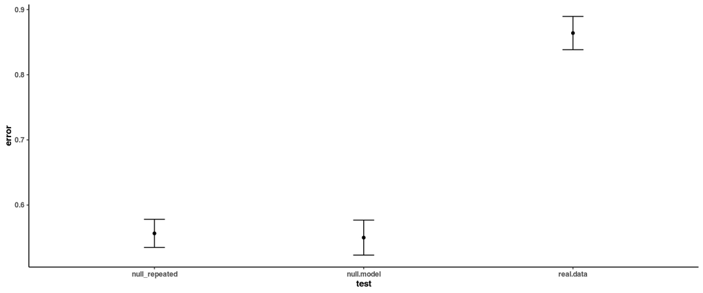

```r
jk_res <- read.csv("./data/processed/jacknifed_random_forest_error.csv")

jk_res$error <- 1 - jk_res$error

agg_jk_res <- aggregate(error ~ test, data = jk_res, FUN = mean)

agg_jk_res$sd <- aggregate(error ~ test, data = jk_res, FUN = sd)$error

ggplot(agg_jk_res, aes(x = test, y = error)) +
  geom_point() +
  geom_errorbar(aes(ymin = error - sd, ymax = error + sd), width = 0.1) +  theme_classic()
```